# Binary Logistic Regression: Model Specification, Comparison, and Interpretation

- Show All Code
- Hide All Code
- View Source

Author

Megan Sutton

## Overview

This reproducible statistical report will demonstrate how to estimate binary logistic regression models and justify decisions about model specification and selection.

You will complete the analysis in **R**, document your workflow in **Quarto**, and publish the rendered report using **GitHub Pages**.

### **Learning objectives**

By the end of this report, you will understand how to:

1. **Specify multiple binary logistic regression models** based on substantive predictions.
2. **Estimate and compare** nested binary logistic regression models using AIC, BIC and likelihood-ratio tests.
3. **Evaluate binary logistic regression assumptions** and identify potentially influential observations.
4. **Select** a preferred model and **justify** that decision.
5. **Extract, report, and interpret** binary logistic regression coefficients using `broom.mixed::tidy()`.
6. **Visualize** your data using the `ggeffects::gpredict()`
7. **Communicate** your analysis in a reproducible Quarto report.

## **Part 1: Configure your project and examine the data**

### **1.1. Load the required packages and organize the dataset**

We will use the `titanic_train` dataset from the `titanic` package. This dataset has been adapted to enhance interpretability and ensure that we are working with the same number of cases for each model.

This dataset contains data on **714 passengers**. The binary outcome variable is `Survived`: whether the passenger survived or died in the Titanic crash. Several other variables summarize characteristics of the Titanic passengers that could influence survival. For this example, four variables will be the focus of this analysis.

| **Variable** | **Description** | **Role** |
| --- | --- | --- |
| Survived | Whether a passenger survived or died in the crash | Outcome |
| Sex | Sex reported on legal documents | Predictor |
| Age | Self-reported age | Predictor |
| Pclass | What type of ticket was purchased; our proxy for socioeconomic status (SES) | Predictor |

### **1.2. Explore the data**

Before estimating any models, familiarize yourself with the variables and their cell counts.

```r
#isolating and analyzing the continuous data
continuous.descriptives <- titanic |>
  summarise(
    across(
      c(Age),
      list(Mean = mean, SD = sd, Min = min, Max = max)
    )
  ) |>
  pivot_longer(
    everything(),
    names_to = c("Variable", ".value"),
    names_sep = "_"
  )

#making a table to display continous variable descri[tive]
continuous.descriptives |>
  gt() |>
  fmt_number(columns = where(is.numeric), decimals = 2)
```

| Variable | Mean | SD | Min | Max |
| --- | --- | --- | --- | --- |
| Age | 29.70 | 14.53 | 0.42 | 80.00 |

```r
#creating a table of all categorical variables
titanic |>
  select(Survived.Char, Sex, Pclass.Char) |>
  tbl_summary(
    label = list(
      Survived.Char ~ "Survival",
      Sex ~ "Gender",
      Pclass.Char ~ "Passenger Class"
    ),
    statistic = all_categorical() ~ "{n} ({p}%)",
    missing = "ifany"
  )
```

| **Characteristic** | **N = 714**<sup>1</sup> |
| --- | --- |
| Survival |  |
| Died | 424 (59%) |
| Survived | 290 (41%) |
| Gender |  |
| female | 261 (37%) |
| male | 453 (63%) |
| Passenger Class |  |
| First Class | 186 (26%) |
| Second Class | 173 (24%) |
| Third Class | 355 (50%) |

<sup>1</sup> n (%)

## **Part 2: Specify competing binary logistic regression models**

### **2.1. Develop your predictions**

The chosen predictor variables may be relevant to the survival outcomes, as these characteristics may have influenced the ways in which different passengers were treated during emergency situations. For instance, female passengers may have heightened odds of survival as, particularly in 1912, women are viewed as weak, requiring additional protection. Therefore, female passengers were likely prioritized in emergencies, with efforts made to evacuate them first. Similarly, a passenger’s age may have influenced their odds of survival, as the safety and protection of children are emphasized in emergency situations. Thus, the evacuation of younger participants were likely prioritized, potentially increasing their odds of survival. Lastly, a passenger’s ticket class may have influenced how they were handled in emergency situations. Those in a higher class may have been prioritized, where individuals of higher class may have increased odds of survival. Taken together, a passenger’s sex, age, and class of ticket may influence their odds of survival. These relationships should be explored further.

### **2.2. Specify four nested models**

Estimate the following models:

| **Model** | **Predictors** | **Purpose** |
| --- | --- | --- |
| mod0: Null | Intercept only | Establish a baseline |
| mod1: Sex | Sex | Evaluate sex |
| mod2: Sex + Pclass | Sex, Pclass | Evaluate the additional contribution of ticket class |
| mod3: Sex + Pclass + Age | Sex, Pclass, Age | Evaluate the additional contribution of age |

Use `glmmTMG()` to estimate each model, assigning each fitted model to a clearly named object.

```r
#estimating intercept only model
mod0 <- glmmTMB(
  Survived ~ 1,
  data = titanic,
  family = binomial(link = "logit")
  )

#adding passenger sex to mod0
mod1 <- glmmTMB(
  Survived ~ Sex,
  data = titanic,
  family = binomial(link = "logit")
  )

#adding passenger ticket class to mod1
mod2 <- glmmTMB(
  Survived ~ Sex + Pclass,
  data = titanic,
 family = binomial(link = "logit")
  )

#adding passenger age to mod2
mod3 <- glmmTMB(
  Survived ~ Sex + Pclass + Age,
  data = titanic,
  family = binomial(link = "logit")
  )
```

### **2.3. Explore your fitted models**

After creating the fitted models, we can inspect the respective results to understand what is implied from each model. We can pay particular attention to:

- The estimated binary logistic regression coefficients.
- The direction and magnitude of predictor associations.
- The model AIC and BIC.
- How the intercept changes as additional predictors are included.

```
 Family: binomial  ( logit )
Formula:          Survived ~ 1
Data: titanic

      AIC       BIC    logLik -2*log(L)  df.resid
    966.5     971.1    -482.3     964.5       713


Conditional model:
            Estimate Std. Error z value Pr(>|z|)
(Intercept)  -0.3799     0.0762  -4.985  6.2e-07 ***
---
Signif. codes:  0 '***' 0.001 '**' 0.01 '*' 0.05 '.' 0.1 ' ' 1
```

```
 Family: binomial  ( logit )
Formula:          Survived ~ Sex
Data: titanic

      AIC       BIC    logLik -2*log(L)  df.resid
    754.7     763.8    -375.4     750.7       712


Conditional model:
            Estimate Std. Error z value Pr(>|z|)
(Intercept)   1.1243     0.1439   7.814 5.52e-15 ***
Sexmale      -2.4778     0.1850 -13.392  < 2e-16 ***
---
Signif. codes:  0 '***' 0.001 '**' 0.01 '*' 0.05 '.' 0.1 ' ' 1
```

```
 Family: binomial  ( logit )
Formula:          Survived ~ Sex + Pclass
Data: titanic

      AIC       BIC    logLik -2*log(L)  df.resid
    680.4     698.7    -336.2     672.4       710


Conditional model:
            Estimate Std. Error z value Pr(>|z|)
(Intercept)   2.3338     0.2385   9.784  < 2e-16 ***
Sexmale      -2.5721     0.2032 -12.658  < 2e-16 ***
Pclass2      -0.9261     0.2580  -3.590 0.000331 ***
Pclass3      -1.9748     0.2379  -8.300  < 2e-16 ***
---
Signif. codes:  0 '***' 0.001 '**' 0.01 '*' 0.05 '.' 0.1 ' ' 1
```

```
 Family: binomial  ( logit )
Formula:          Survived ~ Sex + Pclass + Age
Data: titanic

      AIC       BIC    logLik -2*log(L)  df.resid
    657.3     680.1    -323.6     647.3       709


Conditional model:
             Estimate Std. Error z value Pr(>|z|)
(Intercept)  3.777013   0.401114   9.416  < 2e-16 ***
Sexmale     -2.522782   0.207391 -12.164  < 2e-16 ***
Pclass2     -1.309800   0.278063  -4.710 2.47e-06 ***
Pclass3     -2.580626   0.281437  -9.169  < 2e-16 ***
Age         -0.036985   0.007656  -4.831 1.36e-06 ***
---
Signif. codes:  0 '***' 0.001 '**' 0.01 '*' 0.05 '.' 0.1 ' ' 1
```

In these analyses, the intercept describes the log-odds of survival for the reference group. In the intercept-only model (i.e., mod0), the intercept describes a passenger’s log-odds of survival, regardless of sex, ticket class, or age (i.e., the baseline probability of survival when no other predictors are controlled for). When a passenger’s sex is added to the model (i.e., mod1), the intercept describes the log-odds of survival for female passengers and increases substantially compared to the intercept-only model. When a passenger’s class is added to the model, the intercept describes the log-odds of survival for first class, female passengers and increases again compared to the previous model. Lastly, when a passenger’s age is added to the model, the intercept describes the log-odds of survival for a first class, female passenger who is 0 years old. The intercept in this model is the largest compared to all previous models.

## **Part 3: Compare model performance**

We can now compare the four models using **nested-model χ²-tests** and two measures of overall performance.

### **3.1. Conduct nested-model χ²-tests**

Use `anova()` to compare all four models in a single call, in the order mod0, mod1, mod2, mod3.

```r
#running analysis of variance between models to compare fitness
model.tests <- anova(mod0, mod1, mod2, mod3)

model.tests
```

```
Data: titanic
Models:
mod0: Survived ~ 1, zi=~0, disp=~1
mod1: Survived ~ Sex, zi=~0, disp=~1
mod2: Survived ~ Sex + Pclass, zi=~0, disp=~1
mod3: Survived ~ Sex + Pclass + Age, zi=~0, disp=~1
     Df    AIC    BIC  logLik deviance   Chisq Chi Df Pr(>Chisq)
mod0  1 966.52 971.09 -482.26   964.52
mod1  2 754.70 763.84 -375.35   750.70 213.816      1  < 2.2e-16 ***
mod2  4 680.43 698.71 -336.22   672.43  78.269      2  < 2.2e-16 ***
mod3  5 657.28 680.14 -323.64   647.28  25.148      1  5.311e-07 ***
---
Signif. codes:  0 '***' 0.001 '**' 0.01 '*' 0.05 '.' 0.1 ' ' 1
```

The resulting table reveals that each predictor added to the model statistically significantly improves model fit.

```r
#making a data frame of the model tests
model.tests <- model.tests |>
  select(Df, `Chi Df`, Chisq, `Pr(>Chisq)`) |>
  rename(
    Nested.df = `Chi Df`,
    Nested.chisq.stat = Chisq,
    Nested.p.value = `Pr(>Chisq)`)
```

### **3.2. Compare nested model-level performance statistics**

```r
#collecting performance statistics from each model
glance0 <- broom.mixed::glance(mod0)
glance1 <- broom.mixed::glance(mod1)
glance2 <- broom.mixed::glance(mod2)
glance3 <- broom.mixed::glance(mod3)
```

```r
#making a consolidated data frame
glances <- rbind(glance0, glance1, glance2, glance3)
```

We can extract the performance statistics from each model and combine them with the nested-model test results. This allows us to compare the fitness of each model in order to select the most appropriate option.

```r
#making a data frame including the performance stats to compare models
mods <- c(
  "M0: Null",
  "M1: Sex",
  "M2: Sex + Class",
  "M3: Sex + Class + Age"
  )

comparison_table <- cbind(
  Model = mods,
  glances,
  model.tests
)
```

| **Column** | **Meaning** |
| --- | --- |
| Model | Model identifier |
| AIC | Evaluates model fit while penalizing model complexity |
| BIC | Similar to AIC, but applies a stronger penalty for model complexity. |
| logLik | Measures how well a model explains the observed data. |
| deviance | Measures how poorly a model fits the observed data, relative to a perfectly fitting (saturated) model. Obtained by multiplying the logLik by -2. |
| Residual df | Residual degrees of freedom |
| Nested df | Degrees of freedom added by the new predictor(s) |
| Nested χ² | χ²-statistic comparing the model with its predecessor |
| Nested p | p-value for the nested comparison |

```r
#making a table with the performance statistics of each model
comparison_table |>
  select(
    Model,
    AIC,
    BIC,
    logLik,
    deviance,
    df.residual,
    Nested.df,
    Nested.chisq.stat,
    Nested.p.value
  ) |>
  gt() |>
  cols_label(
    Model = "Model",
    AIC = "AIC",
    BIC = "BIC",
    logLik = "Log-likelihood",
    deviance = "Deviance",
    df.residual = "Residual.df",
    Nested.df = "Nested df",
    Nested.chisq.stat = "Nested χ²",
    Nested.p.value = "Nested p"
  ) |>
  fmt_number(
    columns = c(
      AIC,
      BIC,
      logLik,
      deviance,
      Nested.chisq.stat
    ),
    decimals = 3
  ) |>
  fmt(
    columns = Nested.p.value,
    fns = function(x) {
      ifelse(
        is.na(x),
        "—",
        ifelse(x < .001, "< .001", sprintf("%.3f", x))
      )
    }
  ) |>
  sub_missing(
    columns = c(Nested.df, Nested.chisq.stat),
    missing_text = "—"
  )
```

| Model | AIC | BIC | Log-likelihood | Deviance | Residual.df | Nested df | Nested χ² | Nested p |
| --- | --- | --- | --- | --- | --- | --- | --- | --- |
| M0: Null | 966.516 | 971.087 | −482.258 | 964.516 | 713 | — | — | — |
| M1: Sex | 754.700 | 763.842 | −375.350 | 750.700 | 712 | 1 | 213.816 | < .001 |
| M2: Sex + Class | 680.431 | 698.714 | −336.215 | 672.431 | 710 | 2 | 78.269 | < .001 |
| M3: Sex + Class + Age | 657.283 | 680.138 | −323.642 | 647.283 | 709 | 1 | 25.148 | < .001 |

### **3.3. Interpret the comparisons**

The results allow us to compare the fitness of each model and reveal that, considering both model fit and complexity, model 3 is the best fit to the data. Mod3 has the lowest AIC and BIC values, suggesting superior model fit while considering (i.e., penalizing model complexity). This model also has the highest log likelihood, suggesting the model explains the data best of all four models, and the lowest deviance, suggesting the closest model fit relative to a perfectly fitting model.

As predictors are added to the model, the AIC and BIC values continue to decrease, suggesting that each predictor improves the fit of the model. The largest improvement in model fit occurs when sex is added to the model, followed by class, and then age. Though their relative contributions differ, each predictor improves model fit.

Following a similar pattern, each predictor added to the model produces statistically significant improvements in model fit, according to the likelihood-ratio tests, as identified by the nested p value. The addition of sex to the model (mod1) significantly improved fit compared to the intercept-only model (mod0), the addition of class (mod2) significantly improved model fit compared to the previous model (mod1), and the addition of age significantly improved model fit compared to the sex + class model (mod2).

Taken together, the AIC, BIC, and likelihood-ratio tests support the same conclusions. The overall pattern of findings suggest that the contribution of each predictor significantly improves the fitness of the model, thus the final model (mod3) is the most promising model.

## **Part 4: Evaluate binary logistic regression diagnostics**

### **4.1. Examine the assumptions**

After selecting the most appropriate model, we can examine its compliance with various assumptions.

```r
#selecting the most appropriate model
selected_row <- comparison_table |>
  filter(Nested.p.value < .05) |>
  slice_tail(n = 1)

#creating an object with our selected model's name for dynamic reporting
selected_name <- selected_row$Model

#case matching for dynamic reporting
selected_model <- switch(
  selected_name,
  "M0: Null" = mod0,
  "M1: Sex" = mod1,
  "M2: Sex + Class" = mod2,
  "M3: Sex + Class + Age" = mod3)
```

The provisionally selected model is **M3: Sex + Class + Age**.

Its performance is:

- AIC = **657.283**
- BIC = **680.138**

We will now examine whether the selected model has important diagnostic problems.

Evaluate the following binary logistic regression assumptions:

- **Linearity to the logit scale:** Is the relationship between predictors and the outcome adequately represented by the model? Is the residual variability reasonably uniform across fitted values? (use `DHARMa::` diagnostic plots)

```r
#exploring linearity
set.seed(9041)
res_mod3 <- simulateResiduals(mod3, n = 500, plot = FALSE)
```

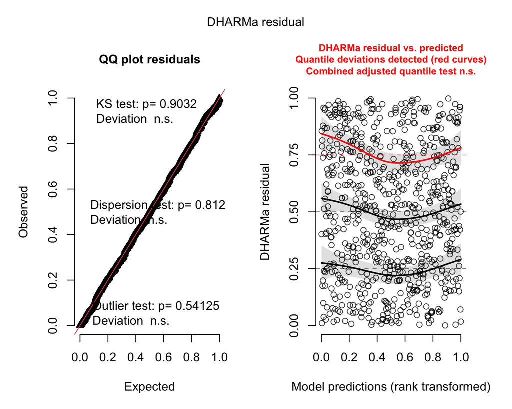

- **Collinearity:** Are predictors so strongly related that their unique contributions may be difficult to estimate precisely?

```
# Check for Multicollinearity

Low Correlation

   Term  VIF   VIF 95% CI adj. VIF Tolerance Tolerance 95% CI
    Sex 1.07 [1.04, 1.12]     1.04      0.93     [0.90, 0.97]
 Pclass 1.42 [1.32, 1.52]     1.09      0.71     [0.66, 0.76]
    Age 1.33 [1.24, 1.43]     1.15      0.75     [0.70, 0.80]
```

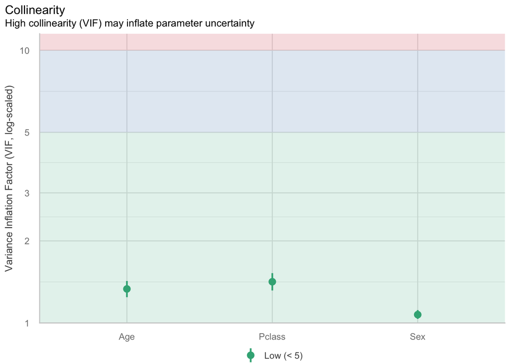

- **Complete separation:** Does any predictor perfectly predict the outcome variable?

We should not have predictor(s) that **perfectly** predict the outcome variable. Therefore, it is important to check for symptoms for this in your preferred model. The main symptom are:

- Very large coefficients and standard errors
- `glmmTMB`warnings about convergence
- Fitted probabilities of essentially 0 or 1 for some groups
- **Influential observations:** Are there observations that may disproportionately influence the fitted model? (use `DHARMa::` again)
- **Events per predictor:** Are there enough events for each coefficient of your predictor variable?

These diagnostics should inform your final model selection. A model with slightly better fit statistics may not be preferable if its assumptions are seriously compromised. For the purposes of this worked example, we retain the provisionally selected model for the reporting demonstration.

### **4.2. Report your diagnostic findings**

To gain further insight on the fitness of your model, several diagnostic tests should be run to inform the final selection. For instance, we can examine the model’s linearity on the logit scale. Here, we are exploring if the relationship between predictors and the outcome adequately are represented by the model and if the residual variability reasonably uniform across fitted values? In the Q.Q. plot, we see the K.S. test, Dispersion test, and Outlier tests all yield non-significant results. This suggests that the residuals do not significantly deviate from the expected distribution, there is no evidence of either over- or underdispersion, and no evidence of an unusual amount of outliers. Together, these findings suggest the assumptions surrounding the linearity on the logit scale are reasonably satisfied with no evident potential problems. In the residual vs. model predictions plot, we see some quantile deviations were detected (in the red line). This suggests that there may be some variation in the residuals across predicted values, though these are minor and do not drastically impact our confidence in the model. We can also explore the collinearity, determining if predictors so strongly related that their unique contributions may be difficult to estimate precisely? The variance inflation factor for all included predictors was low, suggesting there was little to no parameter uncertainty, where each predictor has a unique contribution to the model. There are several other tests that can be run to speak to different assumptions, including complete separation, influential observations, and events per predictor. Ultimately, while one should not treat these tests as a mechanical checklist, rather inform the way in which we can interpret the findings of the model and the confidence that we can have in its results.

## **Part 5: Select and report your preferred model**

### **5.1. Select a model**

Following the diagnostic tests, we can identify the model you believe provides the most defensible representation of the relationship between surviving the sinking of the Titanic and our passenger-specific variables.

Your decision should consider:

- Nested-model χ²-tests.
- AIC.
- BIC.
- Model complexity.
- Diagnostic findings.
- Substantive interpretability.

You are **not required to select the most complex model**.

Considering the findings across all the tests we have run to this point, the model that provides the most defensible representation of the relationship between surviving the sinking of the titanic and our passenger-specific variables is model 3. Accounting for a passenger’s sex, ticket class, and age, appear to produce the most appropriate model to predict the odds of one’s survival.

### **5.2. Create a coefficient table**

We can now extract the unstandardized binary logistic regression coefficients from your preferred model.

```r
#extracting the coefficients of the chosen model
coefficient_results <- broom.mixed::tidy(
  selected_model,
  effects = "fixed",
  component = "cond",
  conf.int = TRUE,
  conf.level = 0.95)

#visualizing coefficients of chosen model in a table
coefficient_results |>
  select(
    term,
    estimate,
    std.error,
    conf.low,
    conf.high,
    p.value
  ) |>
  gt() |>
  cols_label(
    term = "Predictor",
    estimate = "Estimate",
    std.error = "SE",
    conf.low = "95% CI lower",
    conf.high = "95% CI upper",
    p.value = "p"
  ) |>
  fmt_number(
    columns = c(
      estimate,
      std.error,
      conf.low,
      conf.high
    ),
    decimals = 3
  ) |>
  fmt(
    columns = p.value,
    fns = function(x) {
      ifelse(
        x < .001,
        "< .001",
        sprintf("%.3f", x)
      )
    }
  )
```

| Predictor | Estimate | SE | 95% CI lower | 95% CI upper | p |
| --- | --- | --- | --- | --- | --- |
| (Intercept) | 3.777 | 0.401 | 2.991 | 4.563 | < .001 |
| Sexmale | −2.523 | 0.207 | −2.929 | −2.116 | < .001 |
| Pclass2 | −1.310 | 0.278 | −1.855 | −0.765 | < .001 |
| Pclass3 | −2.581 | 0.281 | −3.132 | −2.029 | < .001 |
| Age | −0.037 | 0.008 | −0.052 | −0.022 | < .001 |

### **5.3. Interpret the coefficients**

These intercept estimate reflects the baseline **log-odds** of survival for a first class, female, passenger who is 0 years old is approximately 3.78.

Holding ticket class and passenger age constant, the **log-odds** of surviving as a male passenger is -2.52 compared to female passengers.

Holding passenger sex and age constant, the **log-odds** of surviving as a second class ticket passenger is -1.31 compared to first class passengers.

Further, holding passenger sex and age constant, the **log-odds** of surviving as a third class ticket passenger is -2.58 compared to first class passengers.

Holding passenger sex and ticket class constant, the **log-odds** of survival decreases by -0.04 each additional year of age after 0 years old.

### **5.4. Report overall model performance**

```r
#making a table of the overall model performance
selected_row |>
  select(
    Model,
    AIC,
    BIC,
    logLik,
    deviance,
    df.residual,
    Nested.df,
    Nested.chisq.stat,
    Nested.p.value
  ) |>
  gt() |>
  cols_label(
    Model = "Model",
    AIC = "AIC",
    BIC = "BIC",
    logLik = "Log-likelihood",
    deviance = "Deviance",
    df.residual = "Residual df",
    Nested.df = "Nested df",
    Nested.chisq.stat = "Nested χ²",
    Nested.p.value = "Nested p"
  ) |>
  fmt_number(
    columns = where(is.numeric),
    decimals = 2
  )
```

| Model | AIC | BIC | Log-likelihood | Deviance | Residual df | Nested df | Nested χ² | Nested p |
| --- | --- | --- | --- | --- | --- | --- | --- | --- |
| M3: Sex + Class + Age | 657.28 | 680.14 | −323.64 | 647.28 | 709.00 | 1.00 | 25.15 | 0.00 |

To this point, we have explored the log-odds ratios of survival on the titanic considering the various predicting variables. We can simplify the interpretation of the results by generating odds ratios, which are easier to understand and use in practice.

Exponentiating the coefficients transforms them from log-odds into odds ratios.

```r
#creating odds ratios from log-odds
exp(fixef(mod3)$cond)
```

```
(Intercept)     Sexmale     Pclass2     Pclass3         Age
43.68537504  0.08023611  0.26987411  0.07572659  0.96369034
```

We can also exponentiate the confidence intervals to obtain 95% confidence intervals for the odds ratios.

```r
#making confidence intervals for the odds ratios
or_ci <- exp(confint(mod3, parm = "beta_"))
or_ci
```

```
                  2.5 %     97.5 %    Estimate
(Intercept) 19.90247237 95.8881870 43.68537504
Sexmale      0.05343656  0.1204762  0.08023611
Pclass2      0.15648543  0.4654238  0.26987411
Pclass3      0.04362034  0.1314643  0.07572659
Age          0.94933776  0.9782599  0.96369034
```

These results suggest the baseline odd ratio of survival for a first class, female, passenger who is 0 years old is approximately 43.69 to 1.

### Interpreting passenger sex

Holding ticket class and passenger age constant, being a male passenger is associated with 92% lower odds of survival than female passengers, 95% CI [94.7, 88].

### Interpreting ticket class

Holding passenger sex and age constant, being a second class ticket passenger is associated with 73% lower odds of survival than first class passengers, 95% CI [84.4, 53.5].

Further, holding passenger sex and age constant, being a third class ticket passenger is associated with 92.4% lower odds of survival than first class passengers, 95% CI [95.6, 86.9].

### Interpreting passenger age

Holding passenger sex and ticket class constant, each additional year of age is associated with 3.6% lower odds of survival, 95% CI [5.1, 2.2].

### **5.6. Visualize one of your predictors using `ggeffects`**

To provide a visual example, we can graphically depict the association between passenger sex and odds of survival predicted by model 3.

```
Survived ~ Sex + Pclass + Age
<environment: 0x12bb6ab48>
```

```
(Intercept)     Sexmale     Pclass2     Pclass3         Age
 3.77701338 -2.52278167 -1.30979967 -2.58062587 -0.03698526
```

```
# Predicted probabilities of Survived

Sex    | Predicted |     95% CI
-------------------------------
male   |      0.54 | 0.44, 0.64
female |      0.94 | 0.90, 0.96

Adjusted for:
* Pclass =     1
*    Age = 29.70
```

[output not shown]

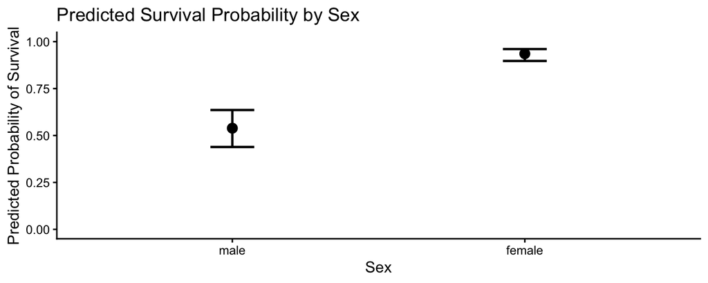

## **Part 6: Discuss your findings and limitations**

What do your results suggest about the relative importance of sex, ticket type (proxy for SES), and age for survival outcomes on the Titanic?

This analysis illustrates how survival outcomes on the Titanic can be investigated considering several passenger characteristics, using several competing regression models.

The model-comparison process allows us to evaluate whether additional predictors explain meaningful variation beyond simpler models.

The final model provides estimates of the associations between passenger sex, ticket class, and age and their odds of survival, revealing younger, first class, female passengers had the highest chances of survival.

However, several limitations should be recognized: